# Statistical Analysis of Body Composition & Health Indicators

Rasha Quadri

2026-03-22

# **Introduction**

Understanding how different aspects of body composition relate to one another is important in health and medical analysis.

This project analyzes relationships between key body composition variables, including **body protein content**, **total body fat ratio**, and **total body water**.

The objectives of this analysis are to:

- Identify relationships between variables
- Build and evaluate regression models
- Assess statistical assumptions
- Interpret results in a meaningful real-world context

Statistical techniques such as **linear regression**, **multiple regression**, and **ANOVA** are used to extract insights from the dataset.

# **Data Preprocessing**

```r
medical <- read.csv("medicaldata2.csv", header = TRUE)

head(medical)
```

```
##   Age Height Weight Gallstone_Status Comorbidity CAD Diabetes_Mellitus
## 1  57    170  143.5                0           0   0                 0
## 2  53    150  108.4                1           1   0                 1
## 3  54    155   80.2                1           0   0                 0
## 4  63    150   69.0                1           0   0                 0
## 5  73    160  104.6                1           1   0                 1
## 6  56    158  100.5                0           0   0                 0
##   Total_Body_Water Total_Body_Fat_Ratio Lean_Mass Body_Protein_Content
## 1             66.2                42.30     57.70                 7.99
## 2             40.0                50.92     48.99                 9.05
## 3             32.8                46.13     53.87                 9.63
## 4             29.9                42.46     57.39                10.49
## 5             52.7                34.20     65.77                11.31
## 6             35.9                49.80     50.25                11.41
##   Hepatic_Fat_Accumulation Glucose Triglyceride    Age_Class
## 1                        3     118          112 Upper Middle
## 2                        2     119           97 Lower Middle
## 3                        2     111          104 Lower Middle
## 4                        2     106           96 Upper Middle
## 5                        3     230          208        Elder
## 6                        3     129           81 Upper Middle
```

## **Converting Variables to Factors**

```r
medical$Gallstone_Status <- factor(medical$Gallstone_Status)
medical$CAD <- factor(medical$CAD)
medical$Diabetes_Mellitus <- factor(medical$Diabetes_Mellitus)

medical$Comorbidity <- factor(
  medical$Comorbidity,
  ordered = TRUE,
  levels = c(0 , 1, 2, 3)
)

medical$Hepatic_Fat_Accumulation <- factor(
  medical$Hepatic_Fat_Accumulation,
  ordered = TRUE,
  levels = c(0, 1, 2, 3)
)

medical$Age_Class <- factor(
  medical$Age_Class,
  ordered = TRUE,
  levels = c("Younger", "Lower Middle", "Upper Middle", "Elder")
)
```

Categorical variables were converted into factors to ensure proper handling in statistical models.

# **Simple Linear Regression**

## **Relationship: Body Protein vs Body Fat**

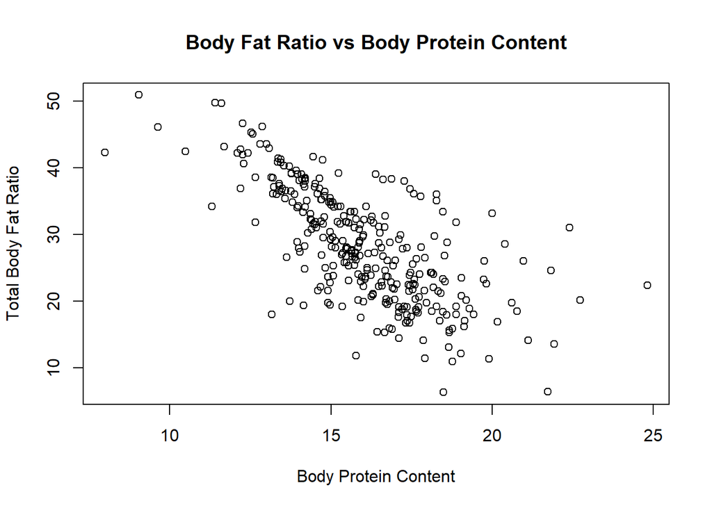

```r
plot(
  medical$Body_Protein_Content,
  medical$Total_Body_Fat_Ratio,
  xlab = "Body Protein Content",
  ylab = "Total Body Fat Ratio",
  main = "Body Fat Ratio vs Body Protein Content"
)
```

```r
model1 <- lm(Total_Body_Fat_Ratio ~ Body_Protein_Content, data = medical)
summary(model1)
```

```
##
## Call:
## lm(formula = Total_Body_Fat_Ratio ~ Body_Protein_Content, data = medical)
##
## Residuals:
##      Min       1Q   Median       3Q      Max
## -17.6717  -3.9411  -0.0006   4.1312  19.5556
##
## Coefficients:
##                      Estimate Std. Error t value Pr(>|t|)
## (Intercept)           70.2057     2.4133   29.09   <2e-16 ***
## Body_Protein_Content  -2.6242     0.1496  -17.54   <2e-16 ***
## ---
## Signif. codes:  0 '***' 0.001 '**' 0.01 '*' 0.05 '.' 0.1 ' ' 1
##
## Residual standard error: 6.032 on 315 degrees of freedom
## Multiple R-squared:  0.4941, Adjusted R-squared:  0.4925
## F-statistic: 307.7 on 1 and 315 DF,  p-value: < 2.2e-16
```

## **Model Diagnostics**

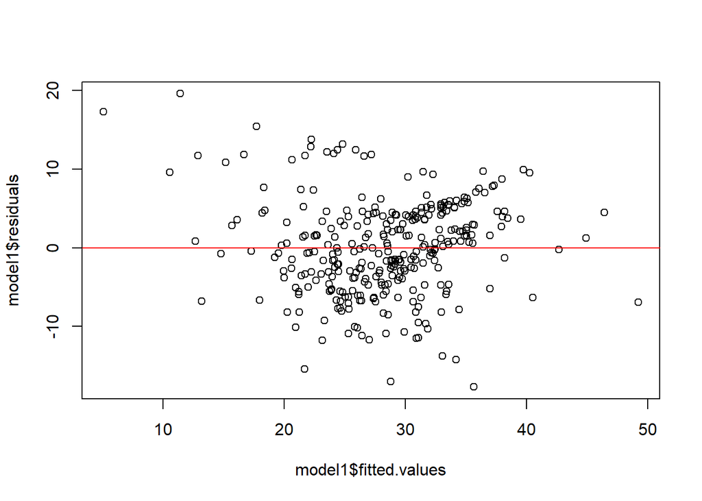

```r
plot(model1$fitted.values, model1$residuals)
abline(h=0,col="red")
```

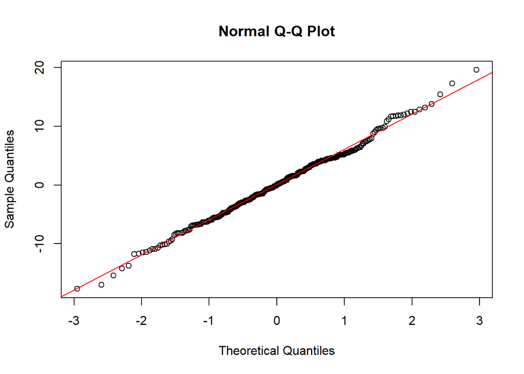

```r
qqnorm(model1$residuals)
qqline(model1$residuals, col="red")
```

```r
shapiro.test(model1$residuals)
```

```
##
##  Shapiro-Wilk normality test
##
## data:  model1$residuals
## W = 0.99561, p-value = 0.5171
```

```r
cor(medical$Total_Body_Fat_Ratio, medical$Body_Protein_Content)
```

```
## [1] -0.7029279
```

## **Interpretation**

There is a clear **negative linear relationship** between body protein content and total body fat ratio.

- The model explains about **49% of the variation** (R<sup>2</sup> = 0.49)
- The predictor is **statistically significant** (p < 0.05)
- Correlation confirms a **strong negative association**

Residual diagnostics show no major violations of assumptions.

**Conclusion**: Higher body protein content is associated with lower body fat.

# **Multiple Linear Regression**

## **Predicting Total Body Water**

```r
model2 <- lm(Total_Body_Water ~ Height + Weight + Body_Protein_Content, data = medical)
summary(model2)
```

```
##
## Call:
## lm(formula = Total_Body_Water ~ Height + Weight + Body_Protein_Content,
##     data = medical)
##
## Residuals:
##     Min      1Q  Median      3Q     Max
## -28.995  -2.278   0.216   2.322  14.976
##
## Coefficients:
##                       Estimate Std. Error t value Pr(>|t|)
## (Intercept)          -45.55001    3.53916 -12.870   <2e-16 ***
## Height                 0.36208    0.03004  12.055   <2e-16 ***
## Weight                 0.29469    0.01807  16.307   <2e-16 ***
## Body_Protein_Content   0.11748    0.12672   0.927    0.355
## ---
## Signif. codes:  0 '***' 0.001 '**' 0.01 '*' 0.05 '.' 0.1 ' ' 1
##
## Residual standard error: 3.741 on 313 degrees of freedom
## Multiple R-squared:  0.7794, Adjusted R-squared:  0.7773
## F-statistic: 368.6 on 3 and 313 DF,  p-value: < 2.2e-16
```

## **Diagnostics**

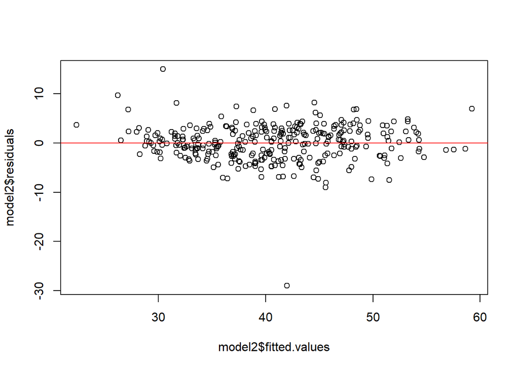

```r
plot(model2$fitted.values, model2$residuals)
abline(h=0, col="red")
```

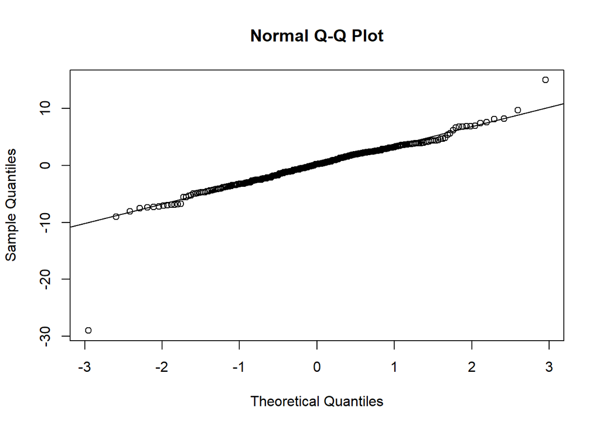

```r
qqnorm(model2$residuals)
qqline(model2$residuals)
```

```r
shapiro.test(model2$residuals)
```

```
##
##  Shapiro-Wilk normality test
##
## data:  model2$residuals
## W = 0.91481, p-value = 2e-12
```

```r
library(lmtest)
dwtest(model2)
```

```
##
##  Durbin-Watson test
##
## data:  model2
## DW = 2.0022, p-value = 0.4822
## alternative hypothesis: true autocorrelation is greater than 0
```

## **Interpretation**

The model explains approximately **78% of the variation** in total body water.

- **Height and Weight** are statistically significant predictors
- **Body Protein Content is not significant**
- No evidence of autocorrelation

**Conclusion**: Body water is primarily driven by physical characteristics (height and weight), not protein content.

# **ANOVA: Age and Body Fat**

## **Research Question**

Does body fat differ across age groups?

```r
library(car)

anova_model <- aov(Total_Body_Fat_Ratio ~ Age_Class, data = medical)
summary(anova_model)
```

```
##              Df Sum Sq Mean Sq F value  Pr(>F)
## Age_Class     3   1305   435.1    6.38 0.00033 ***
## Residuals   313  21347    68.2
## ---
## Signif. codes:  0 '***' 0.001 '**' 0.01 '*' 0.05 '.' 0.1 ' ' 1
```

## **Assumption Checks**

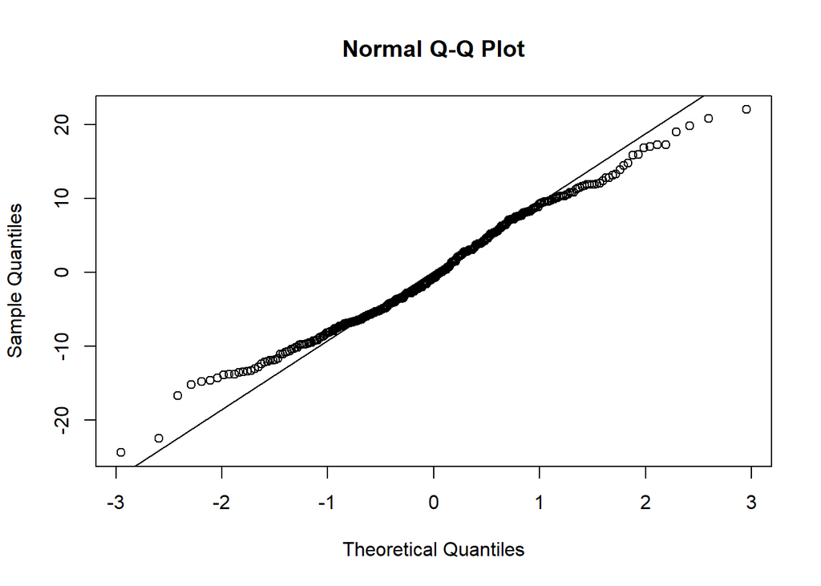

```r
qqnorm(residuals(anova_model))
qqline(residuals(anova_model))
```

```r
shapiro.test(residuals(anova_model))
```

```
##
##  Shapiro-Wilk normality test
##
## data:  residuals(anova_model)
## W = 0.98979, p-value = 0.02595
```

```r
leveneTest(Total_Body_Fat_Ratio ~ Age_Class, data = medical)
```

```
## Levene's Test for Homogeneity of Variance (center = median)
##        Df F value Pr(>F)
## group   3  1.1015 0.3487
##       313
```

## **Visualization**

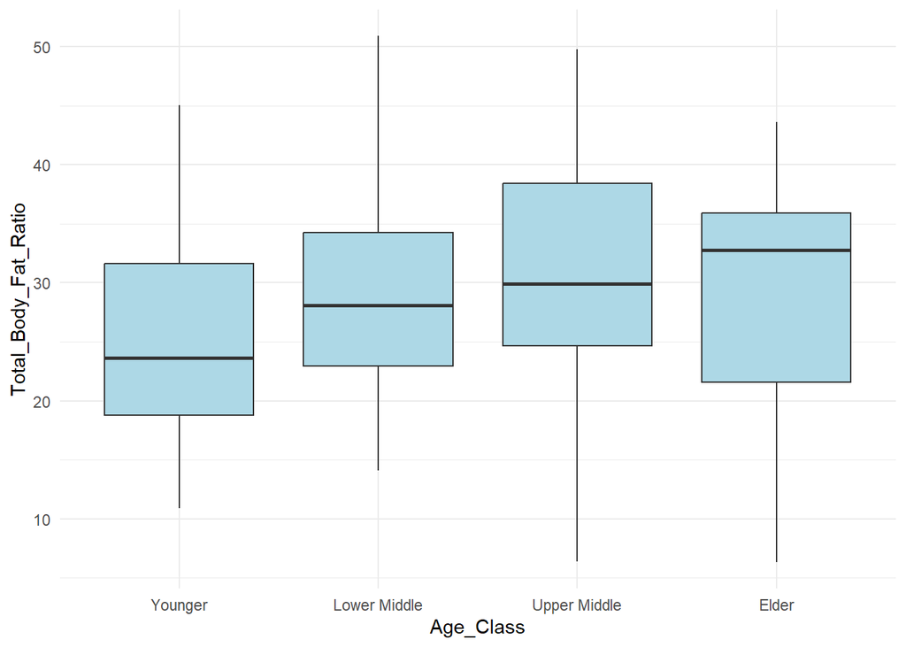

```r
library(ggplot2)

ggplot(medical, aes(x=Age_Class, y=Total_Body_Fat_Ratio))+
  geom_boxplot(fill="lightblue")+
  theme_minimal()
```

## **Interpretation**

The ANOVA test is **statistically significant (p < 0.05)**, indicating that body fat differs across age groups.

**Conclusion**: Age plays a meaningful role in body fat distribution.

# **Two-Way ANOVA: Triglyceride Levels**

## **Research Question**

Do diabetes and hepatic fat affect triglyceride levels?

```r
model3 <- aov(Triglyceride ~ Diabetes_Mellitus * Hepatic_Fat_Accumulation, data = medical)
summary(model3)
```

```
##                                             Df  Sum Sq Mean Sq F value   Pr(>F)
## Diabetes_Mellitus                            1  132956  132956  15.853 8.54e-05
## Hepatic_Fat_Accumulation                     3  299137   99712  11.890 2.17e-07
## Diabetes_Mellitus:Hepatic_Fat_Accumulation   3   16778    5593   0.667    0.573
## Residuals                                  309 2591444    8387
##
## Diabetes_Mellitus                          ***
## Hepatic_Fat_Accumulation                   ***
## Diabetes_Mellitus:Hepatic_Fat_Accumulation
## Residuals
## ---
## Signif. codes:  0 '***' 0.001 '**' 0.01 '*' 0.05 '.' 0.1 ' ' 1
```

## **Assumptions**

```r
shapiro.test(residuals(model3))
```

```
##
##  Shapiro-Wilk normality test
##
## data:  residuals(model3)
## W = 0.83805, p-value < 2.2e-16
```

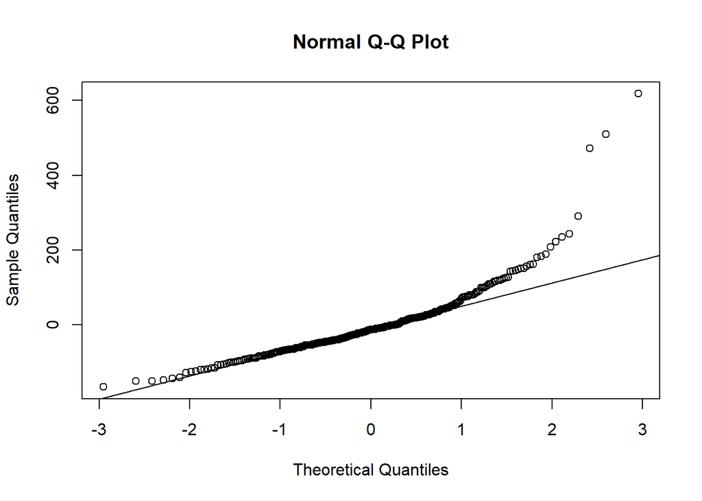

```r
qqnorm(residuals(model3))
qqline(residuals(model3))
```

```r
leveneTest(Triglyceride ~ Diabetes_Mellitus * Hepatic_Fat_Accumulation, data = medical)
```

```
## Levene's Test for Homogeneity of Variance (center = median)
##        Df F value    Pr(>F)
## group   7  4.9856 2.298e-05 ***
##       309
## ---
## Signif. codes:  0 '***' 0.001 '**' 0.01 '*' 0.05 '.' 0.1 ' ' 1
```

## **Visualization**

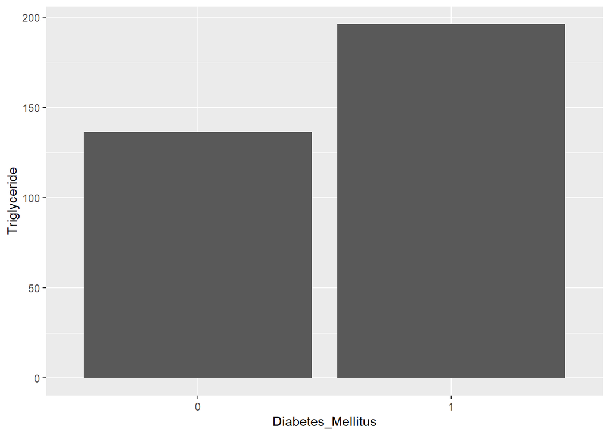

```r
ggplot(medical, aes(x=Diabetes_Mellitus, y=Triglyceride))+
  stat_summary(fun=mean, geom="bar")
```

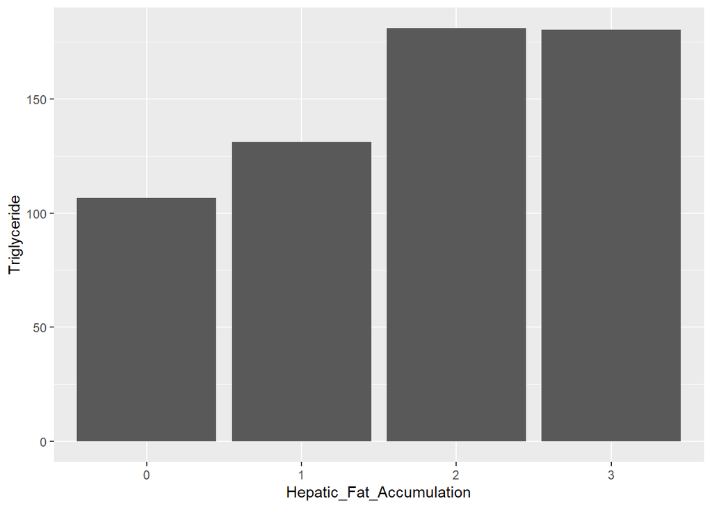

```r
ggplot(medical, aes(x=Hepatic_Fat_Accumulation, y=Triglyceride))+
  stat_summary(fun=mean, geom="bar")
```

## **Interpretation**

- The **interaction effect is not significant**, meaning the effect of diabetes does not depend on hepatic fat level
- Both variables have **significant individual effects**

**Conclusion:**

- Diabetes is associated with higher triglyceride levels
- Hepatic fat accumulation also increases triglycerides
- These effects act independently

# **Key Insights**

- Body protein is strongly associated with **lower body fat**
- Height and weight are the **main drivers of body water**
- Age significantly affects **body fat distribution**
- Diabetes and hepatic fat both impact **triglyceride levels**

# **Conclusion**

This project demonstrates how statistical modeling techniques can be used to analyze real-world health data.

By applying regression and ANOVA methods, we identified key predictors, evaluated assumptions, and extracted meaningful insights from the dataset.

These methods provide a strong foundation for data-driven decision making in health and medical contexts.